# PCA

Riham Abdu

2025-03-18

```r
library(ggplot2)
library(ggfortify)
library(dplyr)
library(tidyr)
library(readr)
library(FactoMineR)
library(factoextra)
library(cluster)
library(fossil)
library(gridExtra)
library(MASS)
# Load Data
#setwd("/Users/riham78/Documents/GitHub/DATA-481-Team-Virology/Riham/R Try1 heatmap n40")
gex_data <- read.csv("data/KSV_Gex_Reduced.csv", row.names = 1)
head(gex_data)
```

```
##              K1         K3     Orf70        K4        K5         K7     Orf16
## 180  -1.4159873 -0.7334076 -2.356423 -2.755006 -2.341402  -2.555724 -5.406533
## 220  -1.4159873  3.6895106 -2.356423 -2.968253  7.777975 -14.070594 -5.406533
## 225  -0.2309708 -2.8683047 -1.171407 -1.783236 -4.401256  -1.225577 -4.221517
## 316  -1.4159873  4.4461471  8.172779  8.500950  5.727930  13.578608  5.408068
## 541  -0.4391203 -1.4097876 -2.356423 -1.024719  5.249028  -2.225293 -5.406533
## 1167 -1.4159873  9.7168461 10.150411  4.285248  5.165561  11.311240  5.571884
##           Orf17     Orf18      Orf4     Orf20       Orf21      Orf22     Orf23
## 180   1.1208136 -3.364880 -6.617685 -3.793810  3.19049751 -4.1234092 -5.000418
## 220  -3.9391216  7.339368 -7.360932  0.203889  0.03016874 -4.1234092 -5.000418
## 225  -2.7541051 -2.179863  1.764085 -2.608794 -2.00764657 -2.9383927 -3.815401
## 316   1.3704796 -3.364880  9.314937  5.415711 -0.85292892  4.9760591  3.409183
## 541  -0.3913211 -3.364880 -4.314065 -3.793810  5.60773760  4.2967911 -5.000418
## 1167  7.7202124 -3.364880 -6.001987 -1.514443  1.34855960 -0.2844645  4.902999
##           Orf24      Orf25     Orf26     Orf27       Orf6     Orf29      Orf30
```

[output cut: 55 more lines]

```r
clusters <- read_csv("data/sample_clusters.csv")
head(clusters)
```

```
## # A tibble: 6 × 2
##   sample_id cluster
##       <dbl>   <dbl>
## 1       180       2
## 2       220       2
## 3       225       2
## 4       316       1
## 5       541       2
## 6      1167       1
```

```r
gex_data1 = gex_data[-18,]  # removed outlier
nrow(gex_data1)
```

```
## [1] 35
```

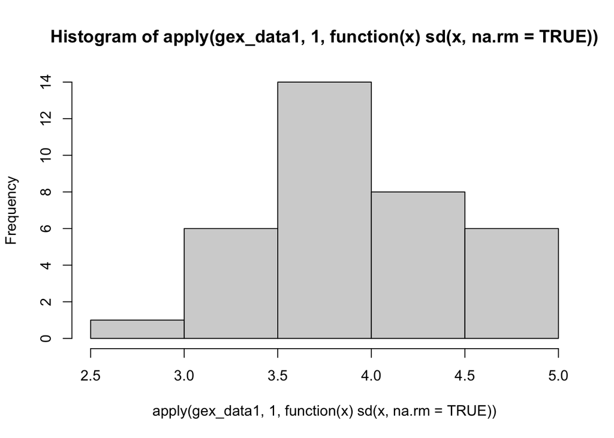

```r
hist(apply(gex_data1,1, function(x) sd(x, na.rm = TRUE)))
```

```r
#Perform PCA
pca_result <- prcomp(gex_data1)
summary(pca_result)
```

```
## Importance of components:
##                            PC1      PC2     PC3     PC4     PC5     PC6     PC7
## Standard deviation     38.0640 12.27411 9.68493 8.81190 7.70429 7.17739 6.16279
## Proportion of Variance  0.6466  0.06723 0.04186 0.03465 0.02649 0.02299 0.01695
## Cumulative Proportion   0.6466  0.71381 0.75567 0.79032 0.81681 0.83980 0.85674
##                           PC8     PC9    PC10    PC11    PC12   PC13    PC14
## Standard deviation     6.0445 5.80233 5.46391 5.03458 4.75491 4.5886 4.46040
## Proportion of Variance 0.0163 0.01502 0.01332 0.01131 0.01009 0.0094 0.00888
## Cumulative Proportion  0.8730 0.88807 0.90140 0.91271 0.92280 0.9322 0.94107
##                           PC15    PC16    PC17    PC18    PC19    PC20    PC21
## Standard deviation     4.21777 3.90719 3.74591 3.45242 3.30161 3.16966 2.92210
## Proportion of Variance 0.00794 0.00681 0.00626 0.00532 0.00486 0.00448 0.00381
## Cumulative Proportion  0.94901 0.95582 0.96209 0.96740 0.97227 0.97675 0.98056
##                           PC22   PC23    PC24    PC25    PC26    PC27    PC28
## Standard deviation     2.72707 2.4587 2.23511 2.07962 2.01360 1.85046 1.75426
## Proportion of Variance 0.00332 0.0027 0.00223 0.00193 0.00181 0.00153 0.00137
## Cumulative Proportion  0.98388 0.9866 0.98881 0.99074 0.99255 0.99408 0.99545
##                           PC29    PC30    PC31   PC32    PC33    PC34      PC35
## Standard deviation     1.64685 1.46431 1.36166 1.2496 1.03362 0.92570 2.832e-15
## Proportion of Variance 0.00121 0.00096 0.00083 0.0007 0.00048 0.00038 0.000e+00
## Cumulative Proportion  0.99666 0.99762 0.99844 0.9991 0.99962 1.00000 1.000e+00
```

```r
pca_result1 <- PCA(gex_data1,scale. = TRUE, graph = FALSE)
```

```r
eigenvalues <- pca_result1$eig
head(eigenvalues[, 1:2])
```

```
##        eigenvalue percentage of variance
## comp 1  37.345401              58.352190
## comp 2   5.498580               8.591531
## comp 3   2.478181               3.872158
## comp 4   2.421143               3.783036
## comp 5   2.136736               3.338651
## comp 6   1.584732               2.476144
```

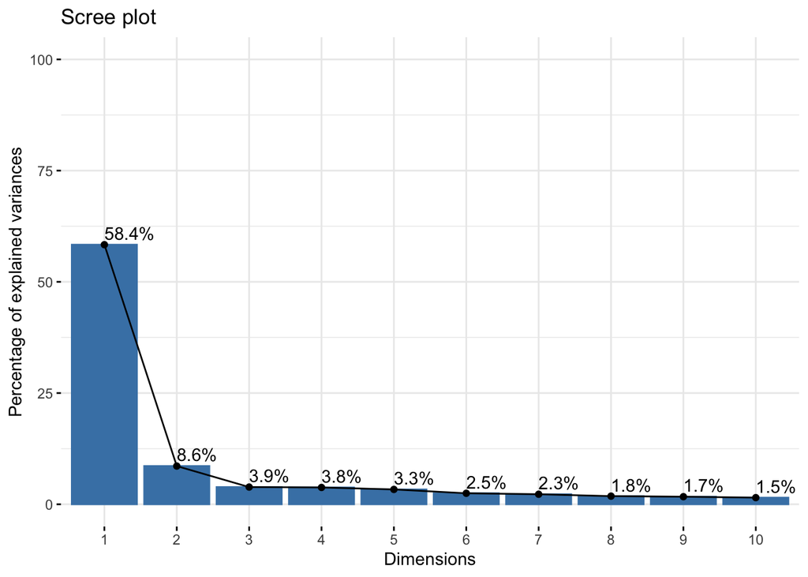

```r
#Scree plot
fviz_eig(pca_result1, addlabels = TRUE, ylim = c(0, 100))
```

```r
#Create a Mapping from sample_id to cluster
clusters_filtered <- clusters$cluster[match(rownames(pca_result$x), clusters$sample_id)]

# Convert clusters to a character vector for modification
custom_colors <- as.character(clusters_filtered)

# Assign a distinct label for sample_id == 6268
custom_colors[rownames(pca_result$x) == "6268"] <- "sample_6268"

# Convert back to factor (ensures discrete color mapping)
custom_colors <- as.factor(custom_colors)

# Define color palette (assign yellow for cluster 1, and red for 6268)
unique_cluster_colors <- scales::hue_pal()(length(unique(na.omit(clusters_filtered))))
highlight_palette <- unique_cluster_colors
highlight_palette[1] <- "orange"  # Assign yellow to cluster 1
highlight_palette <- c(highlight_palette, "red")  # Adds red for 6268

# Define shape and size mapping
custom_shapes <- rep(1, length(levels(custom_colors)))  # Open circles for all
custom_sizes <- rep(3, length(levels(custom_colors)))   # Base size 3 for all
custom_sizes[levels(custom_colors) == "sample_6268"] <- 6  # Larger size for 6268
```

```
## Too few points to calculate an ellipse
```

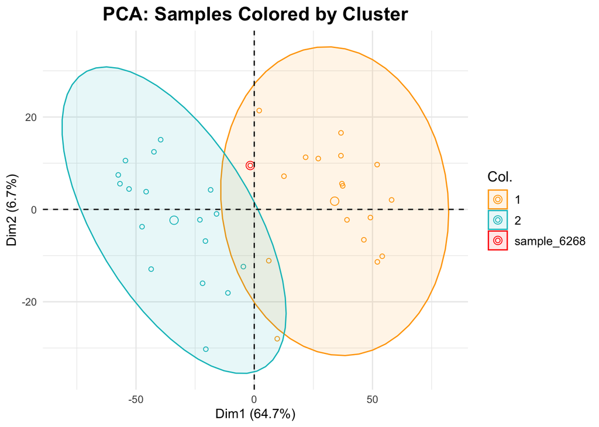

```r
# PCA (1,2)
 fviz_pca_ind(
  pca_result,
  geom.ind = "point",             # Show points for samples
  col.ind = custom_colors,,        # Color individuals by Cluster
  palette = highlight_palette,                # Use journal color palette
  addEllipses = TRUE,             # Add confidence ellipses
  ellipse.level = 0.95,           # Confidence level for ellipses
  label = "none",                 # Remove labels
  title = "PCA: Samples Colored by Cluster"
) +
   scale_shape_manual(values = custom_shapes) + # Open circles
  scale_size_manual(values = custom_shapes) +  # Increase size
  theme_minimal() +
  theme(
    plot.title = element_text(size = 16, face = "bold", hjust = 0.5),
    legend.title = element_text(size = 12),
    legend.text = element_text(size = 10)
  )
```

```
## Too few points to calculate an ellipse
```

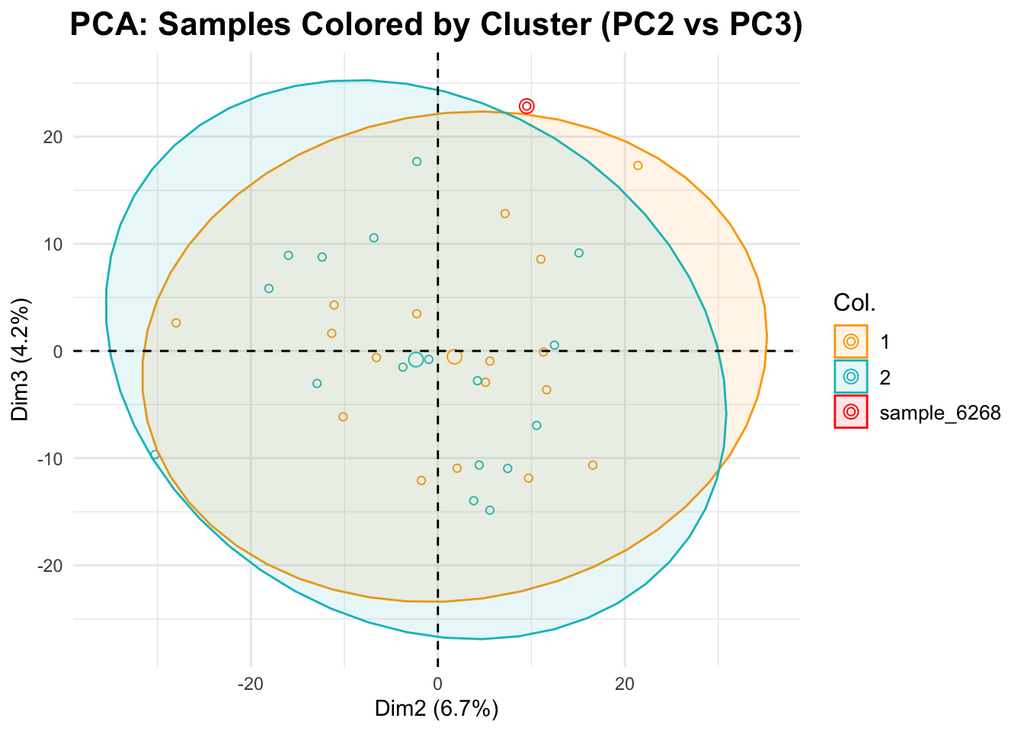

```r
# PCA(2,3)
 fviz_pca_ind(
  pca_result,
  axes = c(2, 3),                 # Specify axes for PCA components 2 and 3
  geom.ind = "point",             # Show points for samples
  col.ind =  custom_colors,    # Color individuals by Cluster
  palette = highlight_palette,                # Use journal color palette
  addEllipses = TRUE,             # Add confidence ellipses
  ellipse.level = 0.95,           # Confidence level for ellipses
  label = "none",                 # Remove labels
  title = "PCA: Samples Colored by Cluster (PC2 vs PC3)"
) +
   scale_shape_manual(values = custom_shapes) +  # Open circles for all
  scale_size_manual(values = custom_sizes) +  # Increase size
  theme_minimal() +
  theme(
    plot.title = element_text(size = 16, face = "bold", hjust = 0.5),
    legend.title = element_text(size = 12),
    legend.text = element_text(size = 10)
  )
```

```
## Too few points to calculate an ellipse
```

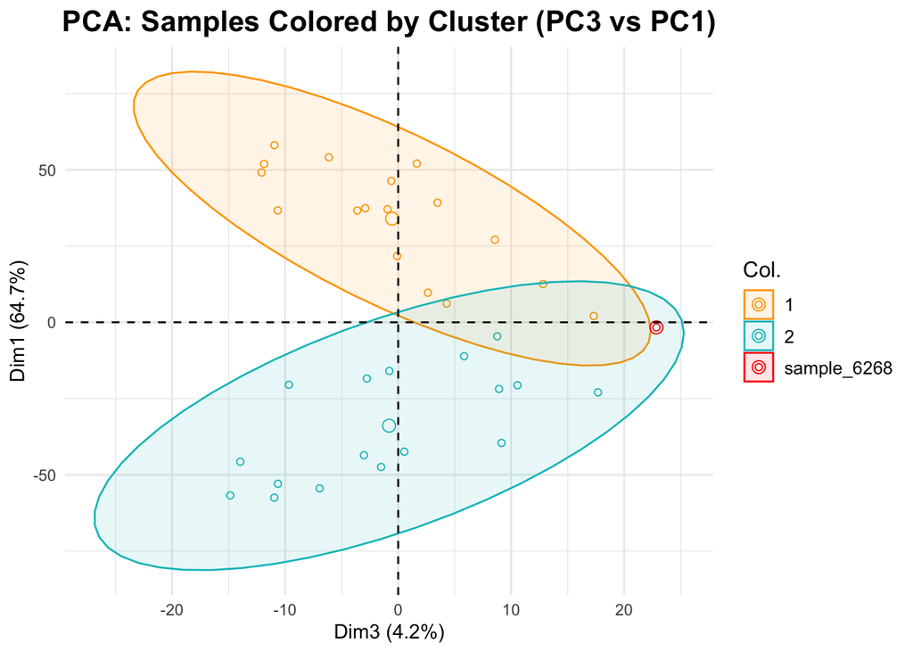

```r
# PCA(3,1)
 fviz_pca_ind(
  pca_result,
  axes = c(3, 1),                 # Specify axes for PCA components 3 and 1
  geom.ind = "point",             # Show points for samples
  col.ind =  custom_colors,    # Color individuals by Cluster
  palette = highlight_palette,                # Use journal color palette
  addEllipses = TRUE,             # Add confidence ellipses
  ellipse.level = 0.95,           # Confidence level for ellipses
  label = "none",                 # Remove labels
  title = "PCA: Samples Colored by Cluster (PC3 vs PC1)"
) +
   scale_shape_manual(values = custom_shapes) +  # Open circles for all
  scale_size_manual(values = custom_sizes) +  # Increase size
  theme_minimal() +
  theme(
    plot.title = element_text(size = 16, face = "bold", hjust = 0.5),
    legend.title = element_text(size = 12),
    legend.text = element_text(size = 10)
  )
```

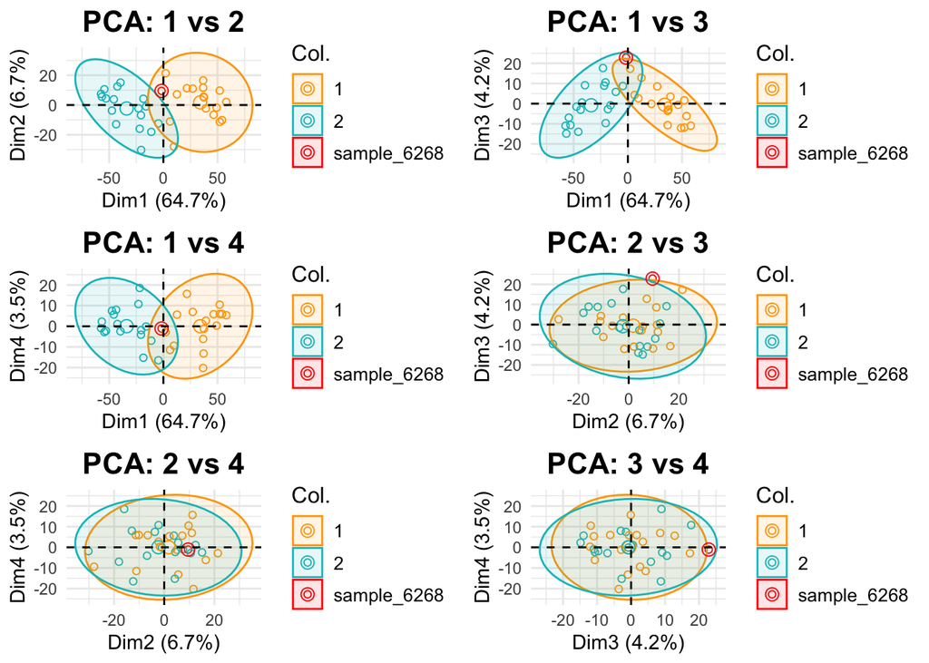

```r
pca_axes_combinations <- list(
  c(1, 2),
  c(1, 3),
  c(1, 4),
  c(2, 3),
  c(2, 4),
  c(3, 4)
)

pca_plots <- list()

# Loop through each combination of axes and store results
for (axes in pca_axes_combinations) {
  # Generate PCA plot for the current combination of axes
  pca_plots[[paste(axes[1], axes[2], sep = "-")]] <- fviz_pca_ind(
    pca_result,
    axes = axes,           # Use specified axes combination
    geom.ind = "point",    # Show points for samples
    col.ind = custom_colors,  # Color by cluster
    palette = highlight_palette,  # Custom color palette
    addEllipses = TRUE,
    ellipse.level = 0.95,
    label = "none",
    title = paste("PCA:", axes[1], "vs", axes[2])
  ) +
    scale_shape_manual(values = custom_shapes) +  # Open circles for all
    scale_size_manual(values = custom_sizes) +    # Increase size for 6268
    theme_minimal() +
    theme(
      plot.title = element_text(size = 16, face = "bold", hjust = 0.5),
      legend.title = element_text(size = 12),
      legend.text = element_text(size = 10)
    )
}

# Combine the individual plots using gridExtra (for facet wrapping)

grid.arrange(grobs = pca_plots, ncol = 2)  # Adjust ncol as necessary
```

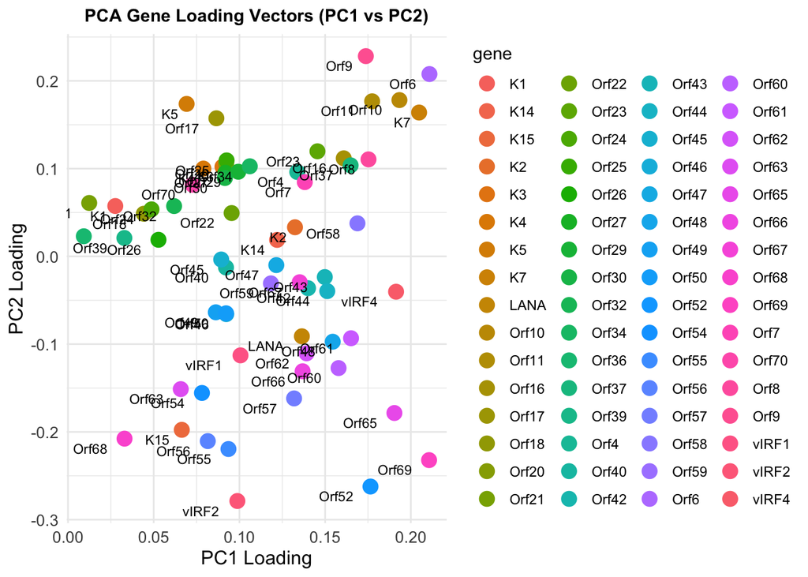

```r
# Step 1: Extract loadings for the first two PCs
loadings <- pca_result$rotation[, 1:2]  # Extract loadings for PC1 and PC2

# Step 2: Prepare the data for plotting
loadings_df <- data.frame(
  gene = rownames(loadings),        # Gene names
  PC1_loading = loadings[, 1],      # Loadings for PC1
  PC2_loading = loadings[, 2]       # Loadings for PC2
)

# Step 3: Plot the loadings using ggplot2
ggplot(loadings_df, aes(x = PC1_loading, y = PC2_loading)) +
  geom_point(aes(color = gene), size = 4) +         # Points for each gene
  geom_text(aes(label = gene), hjust = 1.5, vjust = 1.5, size = 3) +  # Add gene labels
  theme_minimal() +
  ggtitle("PCA Gene Loading Vectors (PC1 vs PC2)") +
  xlab("PC1 Loading") +
  ylab("PC2 Loading") +
  theme(
    plot.title = element_text(size = 11, face = "bold", hjust = 0.5),
    axis.title = element_text(size = 12),
    axis.text = element_text(size = 10)
  )
```

#Each point represents a gene, and the x and y coordinates correspond to its loadings on PC1 and PC2. Genes closer together in this plot have more similar expression profiles, while those that are further apart show greater variability in their expression. Clusters of points suggest that those genes may be co-expressed or share similar functions The position of each point in the plot indicates how much variance each gene contributes to the overall dataset along the principal components.

```r
# 1. Simplest Approach: Simulate Cluster 1 dataset X by i.i.d. sampling N(0, 1)
simulate_simplest_data <- function(n_samples, n_genes, mu, sigma) {
  # Cluster 1: Xj ~ N(0, 1) for j = {1 ... d} and n samples
  X <- matrix(rnorm(n_samples * n_genes), nrow = n_samples, ncol = n_genes)

  # Cluster 2: Y = X + mu (Mean shift)
  Y <- matrix(rnorm(n_samples * n_genes, mean = mu, sd = sigma), nrow = n_samples, ncol = n_genes)

  # Combine the two clusters into a single dataset (Z_simplest)
  Z_simplest <- rbind(X, Y)

  return(Z_simplest)
}

# 2.Simple Approach: Simulate Cluster 1 dataset X and Cluster 2 dataset Y separately
simulate_simple_data <- function(n_samples, n_genes, mu, sigma) {
  # Cluster 1: Xj ~ N(0, 1) for j = {1 ... d} and n samples
  X <- matrix(rnorm(n_samples * n_genes), nrow = n_samples, ncol = n_genes)

  # Cluster 2: Yj ~ N(mu, sigma) for j = {1 ... d} and n samples
  Y <- matrix(rnorm(n_samples * n_genes, mean = mu, sd = sigma), nrow = n_samples, ncol = n_genes)

  # Combine the two clusters into a single dataset (Z_simple)
  Z_simple <- rbind(X, Y)

  return(Z_simple)
}

# 3.Complex Approach: Simulate data using multivariate Gaussian (correlated genes)
simulate_complex_data <- function(n_samples, n_genes, mu, sigma, correlation) {
  # Create the covariance matrix with correlation
  covariance_matrix <- matrix(correlation, n_genes, n_genes)  # Fill with correlation
  diag(covariance_matrix) <- 1  # Set diagonal elements (variances) to 1

  # Cluster 1: Multivariate normal N(mu = 0, sigma = I)
  X <- mvrnorm(n_samples, mu = rep(0, n_genes), Sigma = covariance_matrix)

  # Cluster 2: Multivariate normal N(mu = mu, sigma = I)
  Y <- mvrnorm(n_samples, mu = rep(mu, n_genes), Sigma = covariance_matrix)

  # Combine the two clusters into a single dataset (Z_complex)
  Z_complex <- rbind(X, Y)

  return(Z_complex)
}
```